# Visualisasi Data

Rara Dwi Davisca-Institut Teknologi Statistika dan Bisnis Muhammadiyah

2025-01-16

# Pengantar ggplot2

ggplot2 adalah paket visualisasi data yang sangat populer dalam bahasa pemrograman R, dikembangkan oleh Hadley Wickham. Paket ini memanfaatkan prinsip grammar of graphics untuk memudahkan pengguna dalam membuat grafik yang menarik dan informatif. Dengan sintaks yang sederhana, ggplot2 memungkinkan pengguna untuk mengubah data menjadi visualisasi yang jelas, membantu dalam analisis dan presentasi data.

Salah satu fitur utama ggplot2 adalah kemampuannya untuk melakukan layering, di mana pengguna dapat menambahkan berbagai elemen ke dalam grafik menggunakan operator +. Ini memungkinkan kombinasi berbagai jenis geometri, seperti titik, garis, dan batang, serta penambahan elemen seperti judul dan label sumbu. Selain itu, aesthetic mapping memungkinkan pengguna untuk mengaitkan variabel data dengan elemen visual, memberikan dimensi tambahan pada grafik.

Dengan dukungan untuk berbagai jenis visualisasi dan kemampuan untuk melakukan analisis mendalam melalui faceting, ggplot2 menjadi alat yang sangat berguna bagi peneliti dan analis data. Paket ini tidak hanya menyajikan data secara visual, tetapi juga membantu pengguna memahami pola dan hubungan dalam data mereka, menjadikannya pilihan utama untuk visualisasi data di R.

# 2. Dasar-Dasar ggplot2

## 2.1. Introduction

ggplot2 adalah paket visualisasi data yang populer dalam R, yang memanfaatkan prinsip grammar of graphics untuk memudahkan pembuatan grafik yang informatif dan menarik.Dasar-dasar ggplot2 terdiri dari beberapa komponen utama: data, aesthetic mapping, geometric objects (geoms), dan statistik. ggplot2 adalah pustaka visualisasi data yang sangat fleksibel dan intuitif. Dengan memahami komponen dasar seperti data, aesthetic mapping, dan geometri, dapat membuat grafik yang menarik dan informatif. Untuk grafik yang lebih kompleks, bisa menambahkan layer, facet, atau kustomisasi tema.

## 2.2 Struktur data ggplot2

grafik di ggplot2 dibangun dengan tiga komponen utama:

Data: Dataset yang akan digunakan untuk visualisasi. Mapping (aes): Hubungan antara variabel dalam data dengan elemen visual seperti posisi, warna, ukuran, dll. Geometri (geom): Tipe grafik yang akan dibuat, misalnya titik, garis, batang, atau histogram.

## 2.3 Dataset

Data yang akan divisualisasikan harus disiapkan dalam bentuk data frame atau tibble agar kompatibel dengan proses visualisasi. Dataset ini harus memiliki variabel-variabel yang relevan untuk keperluan analisis visual, seperti variabel numerik untuk sumbu x dan y, atau variabel kategorik yang dapat digunakan untuk membedakan grup, warna, atau pola tertentu dalam grafik.

## 2.4 Membuat paket ggplot2

Pastikan paket ggplot2 sudah terinstal dan diaktifkan dalam lingkungan R sebelum digunakan. Jika belum terinstal, Anda dapat memasangnya dengan perintah: install.packages(“ggplot2”). Setelah itu, aktifkan paket dengan menjalankan perintah: library(ggplot2).

```r
library(ggplot2)
```

## 2.5 Membuat data frame

Buatlah dua kolom, x dan y, yang masing-masing berisi 100 angka acak dengan distribusi normal. Angka-angka ini dapat dihasilkan menggunakan fungsi rnorm(100) dalam R. Kolom tersebut dapat digunakan sebagai variabel untuk visualisasi data.

```r
data <- data.frame(x = rnorm(100), y = rnorm(100))
```

## 2.6 Membuat Plot,Judul dan Tema

Kita akan membuat visualisasi menggunakan ggplot dengan data frame bernama data. Pada grafik ini, sumbu x diatur untuk merepresentasikan kolom x, sementara sumbu y digunakan untuk kolom y. Grafik diberi judul “Plot Titik” untuk memberikan konteks yang jelas. Selain itu, tema yang digunakan adalah theme_classic() agar grafik tampil lebih sederhana dan elegan dengan gaya klasik.

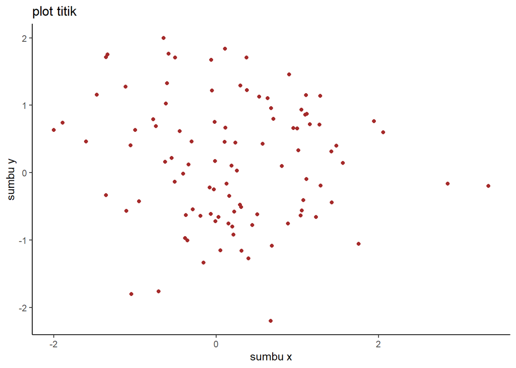

```r
library(ggplot2)
#buat data frame contoh
data <- data.frame(x = rnorm(100), y = rnorm(100))
#buat plot titik
ggplot(data, aes(x = x, y = y)) +
  geom_point( color = "BROWN")  +
  labs(title = "plot titik", x = "sumbu x", y = "sumbu y") +
  theme_classic()
```